# Power Electronics Lab 5 Report

## Pre-Lab Writeup

The lab prep documented specified a flyback converter with the following values:

- Input voltage Vg = 18 V
- Output voltage Vo = 10 V
- Output power Pout = 20 W
- Switching frequency fs = 50 kHz
- Duty cycle D = 35%
- $\alpha$ = 70%
- Assume 60 uF for the output capacitance C
- 5 $\Omega$ is used for the output resistance R to match our lab load resistor

From these values, the following can also be calculated

- Voltage conversion ratio, M = 10/18
- Switching period, $T_s = \frac{1}{fs}$

However, to properly create a digital twin, the following specifications must also be determined:

- Turns ratio a
- Magnetizing inductance, L

Given that the critical inductance ratio, $\alpha$, is less than one, we know the flyback converter operates in discontinuous current mode (DCM). As such, the turns ratio is defined as $$a_{DCM} = \frac{V_o}{V_g} \cdot \frac{\sqrt{\alpha} - D}{D} $$

Our known values stated above can be plugged into this equation as follow: $a_{DCM} = \frac{10}{18} \cdot \frac{\sqrt{0.7} - 0.35}{0.35} = 0.7725 $. As such, the turns ratio of the inductor, $\frac{N_s}{N_p}$, where $N_p$ is the number of turns on the primary side (input) and $N_s$ is the number on the secondary (output) side, must be equal to 0.7725.

The magnetizing inductance for our DCM flyback converter can be found with the following equation from a buck-boost converter (which a flyback converter can be broken down to): $$ D_{DCM} = \sqrt{K} \cdot M, K = \frac{2}{T_s} \cdot \frac{L}{R} $$

This equation can be rearranged to solve for L: $ L = \frac{T_s \cdot R}{2} \cdot (\frac{D}{M})^2 $. Substituting the above values into this equation results in $ L = \frac{{50e3}^{-1} \cdot 5}{2} \cdot (\frac{0.35}{0.\overline{55}}^2) = 19.8 \mu H $

Finally, given all above values, the peak current, $i_{pk} $, can be found: $$ i_{pk} = \sqrt{K} \cdot T_s \cdot \frac{V}{L} = \sqrt{\frac{2}{{50e3}^{-1}} \cdot \frac{19.8e-6}{5}} \cdot \frac{1}{50e3} \cdot \frac{V_o}{19.8e-6} = 6.35 amps $$

The above calculations were verified using the PLECS model using a UC2844 IC. $V_{comp}$ to control this IC was set using the formula found experimentally in Lab 3 to convert from a given $i_{pk}$ value to the nessesary $V_{comp}$ voltage, which works in our DCM operating mode for flyback and well as buck converters.

The output voltage is is slightly less than the desired 10V at 9.85V. However, this difference is minimal.

[figure not shown]

The initialization script is included below:

```python
fs = 50e3;
ts = 1/fs;

R = 5;
Vo = 10;
Vg = 18;
alpha = 0.70;
d = 0.35;

M = Vo/Vg;

L = ((ts*R)/2) * (d/M)^2;
a = (Vo/Vg)*((sqrt(alpha) - d)/d);

K = (2/ts)*(L/R);

Ipk = sqrt(K)*ts*(Vo/L);

Vcomp = (3/20)*Ipk + (13/10);
```

## Task 1

We began by reconfiguring the lab hardware for flyback operation. This involved switching the bottom jumper to flyback (JP7 -> JP8) and moving the diode from D7 to D8. We then installed the provided transformed

#### Q1: Make note of the test transformer label.

- We used test transformer T5.

The complete test setup is shown in the image below:

[figure not shown]

First, shunt voltage, $V_{sh}$, and drain voltage, $V_{drain}$, were measured with the scope for an output voltage set to 4V, 7V, and 9V. The resulting waveforms are shown below.

### 4V Output.

**Q3 Exact Voltage & Output Current:** Input current is 0.28A, while the output voltage is 4.156V.

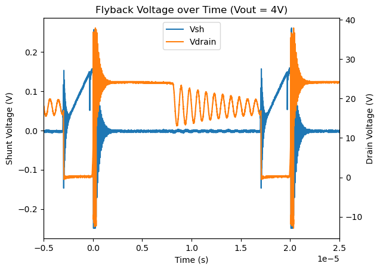

```python
from rigol import read_rigol_csv
from matplotlib import pyplot as plt
import pandas as pd

[t1_4_data, t1_4_d0, t1_4_dt] = read_rigol_csv("data/t1_4.csv")

fig, ax1 = plt.subplots()

ax1.plot(t1_4_data["X"], t1_4_data["CH1"], label="Vsh")
ax1.set_xlabel("Time (s)")
ax1.set_ylabel("Shunt Voltage (V)")

plt.xlim(-0.5e-5, 2.5e-5)
ax2 = ax1.twinx()
ax2.plot(t1_4_data["X"], t1_4_data["CH2"], label="Vdrain", color='tab:orange')
ax2.set_ylabel("Drain Voltage (V)")

plt.title("Flyback Voltage over Time (Vout = 4V)")
lines = ax1.get_lines() + ax2.get_lines()
ax1.legend(lines, [line.get_label() for line in lines], loc='upper center')
```

### 7V Output

**Q3 Exact Voltage & Output Current:** Input current is 0.76A, while the output voltage is 7.03V.

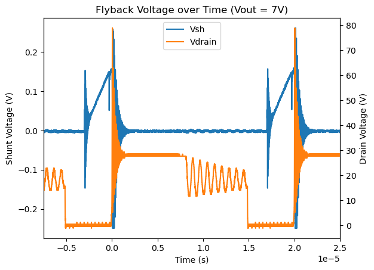

```python
[t1_7_data, t1_7_d0, t1_7_dt] = read_rigol_csv("data/t1_7.csv")

fig, ax1 = plt.subplots()

ax1.plot(t1_7_data["X"], t1_4_data["CH1"], label="Vsh")
ax1.set_xlabel("Time (s)")
ax1.set_ylabel("Shunt Voltage (V)")

plt.xlim(-0.75e-5, 2.5e-5)
ax2 = ax1.twinx()
ax2.plot(t1_7_data["X"], t1_7_data["CH2"], label="Vdrain", color='tab:orange')
ax2.set_ylabel("Drain Voltage (V)")

plt.title("Flyback Voltage over Time (Vout = 7V)")
lines = ax1.get_lines() + ax2.get_lines()
ax1.legend(lines, [line.get_label() for line in lines], loc='upper center')
```

### 9V Output

When attempting to set for a 9V output voltage, we experienced some rather strange behavior with our flyback converter. Once we reached a potentiometer position corresponding to around 8.5V, the flyback converter appeared to become somewhat unstable. The transformer would start producing a verb noticeable buzzing noise and the output voltage would drop by around 1.2V. The resulting output waveforms are shown in a scope capture below:

[figure not shown]

The above-shown behavior happened regardless of the scope trigger behavior. Upon briefly troubleshooting with the instructor, we were unable to determine a cause for this instability. While current control can become unstable above a 50% duty cycle, our duty cycle is much below that 50% threshold, not to mention that the UC2844 can not exceed a 50% duty cycle. However, after leaving the flyback converter at an output voltage configuration slightly below that at which the instability was initially observed for some time (a few minutes), we were able to creep the voltage up close to the desired 9V output. This final output of 8.80V is reflected in our measured data graphed below

**Q3 Exact Voltage & Output Current:** Input current is 1.16A, while the output voltage is 8.80V.

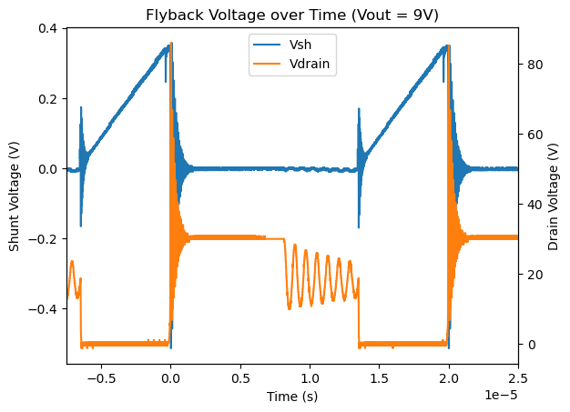

```python
[t1_9_data, t1_9_d0, t1_9_dt] = read_rigol_csv("data/t1_9.csv")

fig, ax1 = plt.subplots()

ax1.plot(t1_9_data["X"], t1_9_data["CH1"], label="Vsh")
ax1.set_xlabel("Time (s)")
ax1.set_ylabel("Shunt Voltage (V)")

plt.xlim(-0.75e-5, 2.5e-5)
ax2 = ax1.twinx()
ax2.plot(t1_9_data["X"], t1_9_data["CH2"], label="Vdrain", color='tab:orange')
ax2.set_ylabel("Drain Voltage (V)")

plt.title("Flyback Voltage over Time (Vout = 9V)")
lines = ax1.get_lines() + ax2.get_lines()
ax1.legend(lines, [line.get_label() for line in lines], loc='upper center')
```

## Task 2

Next, for task 2, the scope probes were connected to $V_{inj-}$ and $V_{dd}$, which are connected to the positive and negative side of the output resistor, respectively. These two values can be used to calculate the output capacitance.

When reviewing these measurements, it is important to note that the signal from $V_{inj-}$ was collected in regular DC coupling mode on the oscilloscope, whereas $V_{dd}$ was measured in AC coupling mode. In AC coupling mode, the DC signal is filtered out such that the AC components of the signal are centered around zero.

These measurements were taken for an output voltage of 4V, 7V, and 9V. Exact output voltages and supply current are noted in the appropriate section.

### 4V Output

A rolling mean is applied to make the overlapping graphed data more readable

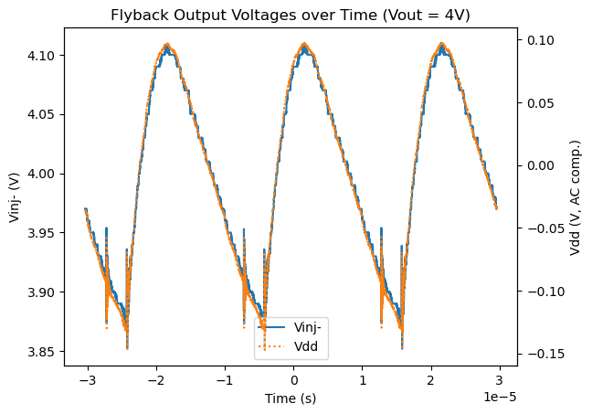

```python
[t2_4_data, t2_4_d0, t2_4_dt] = read_rigol_csv("data/t2_4.csv")

t2_4_data['CH1'] = t2_4_data['CH1'].rolling(10).mean()
t2_4_data['CH2'] = t2_4_data['CH2'].rolling(10).mean()

fig, ax1 = plt.subplots()

ax1.plot(t2_4_data["X"], t2_4_data["CH1"], label="Vinj-", linestyle="-")
ax1.set_xlabel("Time (s)")
ax1.set_ylabel("Vinj- (V)")

#plt.xlim(-0.75e-5, 2.5e-5)
ax2 = ax1.twinx()
ax2.plot(t2_4_data["X"], t2_4_data["CH2"], label="Vdd", color='tab:orange', linestyle="dotted")
ax2.set_ylabel("Vdd (V, AC comp.)")

plt.title("Flyback Output Voltages over Time (Vout = 4V)")
lines = ax1.get_lines() + ax2.get_lines()
ax1.legend(lines, [line.get_label() for line in lines], loc='lower center')
```

### 7V Output

The exact same process is completed for the 7V output. For the 7V output, the exact output voltage was 7.11V, while the input current was 0.78A.

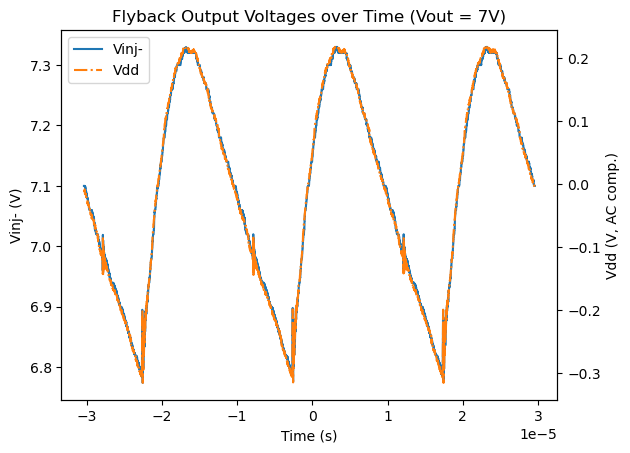

```python
[t2_7_data, t2_7_d0, t2_7_dt] = read_rigol_csv("data/t2_7.csv")

t2_7_data['CH1'] = t2_7_data['CH1'].rolling(10).mean()
t2_7_data['CH2'] = t2_7_data['CH2'].rolling(10).mean()

fig, ax1 = plt.subplots()

ax1.plot(t2_7_data["X"], t2_7_data["CH1"], label="Vinj-", linestyle="-")
ax1.set_xlabel("Time (s)")
ax1.set_ylabel("Vinj- (V)")

#plt.xlim(-0.75e-5, 2.5e-5)
ax2 = ax1.twinx()
ax2.plot(t2_7_data["X"], t2_7_data["CH2"], label="Vdd", color='tab:orange', linestyle="-.")
ax2.set_ylabel("Vdd (V, AC comp.)")

plt.title("Flyback Output Voltages over Time (Vout = 7V)")
lines = ax1.get_lines() + ax2.get_lines()
ax1.legend(lines, [line.get_label() for line in lines], loc='upper left')
```

### 9V Output.

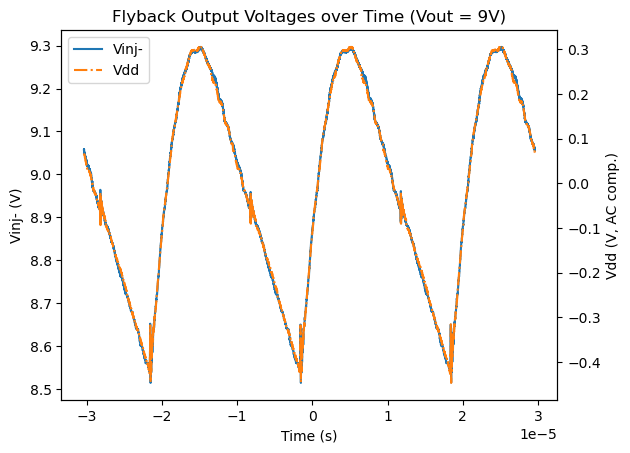

```python
[t2_9_data, t2_9_d0, t2_9_dt] = read_rigol_csv("data/t2_9.csv")

t2_9_data['CH1'] = t2_9_data['CH1'].rolling(10).mean()
t2_9_data['CH2'] = t2_9_data['CH2'].rolling(10).mean()

fig, ax1 = plt.subplots()

ax1.plot(t2_9_data["X"], t2_9_data["CH1"], label="Vinj-", linestyle="-")
ax1.set_xlabel("Time (s)")
ax1.set_ylabel("Vinj- (V)")

#plt.xlim(-0.75e-5, 2.5e-5)
ax2 = ax1.twinx()
ax2.plot(t2_9_data["X"], t2_9_data["CH2"], label="Vdd", color='tab:orange', linestyle="-.")
ax2.set_ylabel("Vdd (V, AC comp.)")

plt.title("Flyback Output Voltages over Time (Vout = 9V)")
lines = ax1.get_lines() + ax2.get_lines()
ax1.legend(lines, [line.get_label() for line in lines], loc='upper left')
```

#### What's happening here?

- The slight noise seen halfway through the capacitor's discharge cycle is when the transistor turns on.
- When the transistor is on, the input and output are completely disconnected as the transformer builds up stored magnetic energy. In this period, only the capacitor is supplying power to the output and it discharges.
- When the transformer is fully charged and the output voltage bottoms out, the transistor turns off. Stored magnetic energy from the transformer begins to flow into both the output and to charge the capacitor. This is the charge-up period seen after the small noise spike at the lowest voltage potential point.
- Given the flyback converter is operating in discontinuous current mode, there reaches a point when the transformer is completely discharged and/or can not supply the required current to maintain the output voltage (given the output resistance and Ohm's Law). This state is the point at which we see the capacitor voltage peak, after which the capacitor begins to discharge to supply the necessary current to the output.
- The cycle then continues to the first stage as the capacitor discharges and repeats.

## Post-Lab Analysis

#### Q7: Use the shunt voltage measurements taken to determine the magnetizing inductance of the test transformer.

To begin, given that we were using a $0.05 \Omega$ shunt resistor, we can use Ohm's Law to calculate the drain current.

```
(-5e-06, 5e-06)
```

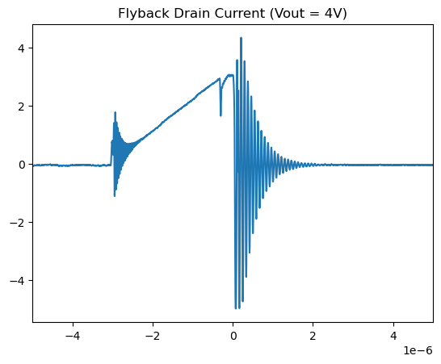

```python
t1_4_data["I"] = (t1_4_data["CH1"] / 0.05).rolling(10).mean()
plt.plot(t1_4_data["X"], t1_4_data["I"])
plt.title("Flyback Drain Current (Vout = 4V)")
plt.xlim(-0.5e-5, 0.5e-5)
```

Looking at the measurements from this data, we can extract a peak drain current (ignoring the spike & oscillations after the transistor turns off) of 3.06 amps. The peak current of the flyback converter operating in DCM (as further described in the pre-lab assignment) is $$ i_{pk} = \sqrt{K} \cdot T_s \cdot \frac{V}{L}, K = \frac{2}{T_s} \cdot \frac{L}{R} $$

With some [Wolfram-Alpha magic](https://www.wolframalpha.com/input?i=i+%3D+sqrt%28%282%2Ft%29*%28l%2Fr%29%29+*+t+*+%28v%2Fl%29%2C+solve+for+l&assumption=%22i%22+-%3E+%22Variable%22), this equation solved for L equals: $$ L = \frac{2 \cdot T_s \cdot {V_o}^2}{{i_{pk}}^2 \cdot R} $$

Solved using our known values of a 50 kHz frequency, $5 \Omega$ load resistance, and 4.156V output voltage results in $ L = \frac{2 \cdot {50e3}^{-1} \cdot 4.156^2}{3.06^2 \cdot 5} = 14.8 \mu H$ magnetizing inductance.

#### Q8: Use the drain measurement to determine the turns ratio 'a' of the transformer.

Given that we have established the flyback converter is operating in DCM, the turns ratio $a_{DCM}$ is defined as $$a_{DCM} = \frac{V_o}{V_g} \cdot \frac{\sqrt{\alpha} - D}{D} $$ where D is the duty cycle and $\alpha$ is the critical inductance ratio.

First is calculating $\alpha$, for which knowing the critical inductance is necessary. The critical inductance is defined as $$ L_{crit} = {(\frac{1}{M + 1})}^2 \cdot R \cdot \frac{T_s}{2} $$ where M is the voltage output ratio, $M = \frac{V_o}{V_g}$. Substituting in all known values and solving results in $ L_{crit} = {(\frac{1}{0.230\overline{8} + 1})}^2 \cdot 5 \cdot \frac{1}{2 \cdot 50e3} = 33.0 \mu H $. The resulting critical inductance ratio based on the magnetizing inductance calculated in Q7 is $ \alpha = \frac{14.8e-6}{33.0e-6} = 45\% $.

The only remaining necessary value is the duty cycle of the transistor. It would be easiest to collect this parameter using the Measure All function of the oscilloscope. However, I didn't think to do this in-lab, so the duty cycle can instead be extracted from the measured drain voltage response. We know the transistor is on when the drain voltage is pulled to ground (approx. to <1 volt), excluding the oscillation when the transistor turns off (hence the > -5 volt condition). From this, we can create a square wave of when the transistor is on. From this square wave, we can apply a derivative to find the exact points the switching occur. Finally, the on time between the points where the transistor switches on and switches off can be compared to the time between cycles (measured between two switch on points) to calculate the duty cycle.

```
14.294276296074305
```

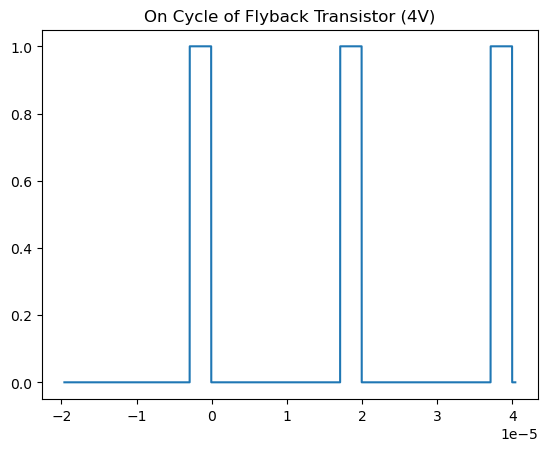

```python
import numpy as np

t1_4_data["on"] = (t1_4_data["CH2"] < 1) & (t1_4_data["CH2"] > -5)
t1_4_data["switch"] = list(np.diff(t1_4_data["on"].astype(int))) + [0]
plt.plot(t1_4_data["X"], t1_4_data["on"])
plt.title("On Cycle of Flyback Transistor (4V)")

switch_on_indices = t1_4_data.index[t1_4_data["switch"] == 1].tolist()
switch_off_indices = t1_4_data.index[t1_4_data["switch"] == -1].tolist()

duty_cycle = (
    (t1_4_data["X"].iloc[switch_off_indices[0]] - t1_4_data["X"].iloc[switch_on_indices[0]]) /
(t1_4_data["X"].iloc[switch_on_indices[1]] - t1_4_data["X"].iloc[switch_on_indices[0]])
)

print(duty_cycle * 100)
```

For a 4V output, the duty cycle is 14.3%.

Finally, all calculated values can be plugged into the original $a_{DCM}$ equation stated above which results in $a_{DCM} = \frac{4.156}{18} \cdot \frac{\sqrt{0.45} - 0.143}{0.143} = 0.8522 $. Therefore, the turns ratio is 0.85.

Given the above calculations, the PLECS model was updated with the calculated magnetizing inductance and turns ratio. The output and initialization scripts are included below.

[figure not shown]

```python
fs = 50e3;
ts = 1/fs;

R = 5;
Vo = 4.156;
Vg = 18;
alpha = 0.70;
d = 0.35;

M = Vo/Vg;

% L = ((ts*R)/2) * (d/M)^2;
L = 14.8e-6
%a = (Vo/Vg)*((sqrt(alpha) - d)/d);
a = 0.85

K = (2/ts)*(L/R)

Ipk = sqrt(K)*ts*(Vo/L)

Vcomp = (3/20)*Ipk + (13/10)
```

#### Q9: Run simulations corresponding to the measurements taken and compare the waveforms (shape, amplitude, timing, duty cycle) of the shunt voltage, drain voltage, and output voltage.

First, looking at the 4V output graphs:

[figure not shown]

and for comparison, the lab from collected data:

[figure not shown]

Comparing each of the following metrics:

- **Shape:** Overall, the big picture shape of both the lab and the simulation is the same. Ths shunt voltage increases linearly as the transistor is on and otherwise rests at zero. The output voltage follows a fairly linear charge and discharge cycle. However, there is a fair amount of noise present in the all of the voltage measurements in lab that isn't present in the simulation. There are (relativly) large oscillations as the transistor turns on in the drain voltage and turns both on and off in the shunt voltage. Small oscillations are observable in the output voltage as the transistor turns on. There is some amount of ringing of the transistor drain voltage starting around halfway through the off cycle and continuing until it turns on.
- **Amplitude:** Aside from the noise in the lab hardware, the shunt voltage is fairly similar between the lab hardware and simulation, which makes sense as the same threshold value is used in controlling the UC2844 in both scenarios. The drain voltage is also roughly the same between both the lab hardware and the simulation. The second voltage level in the transistor's off period is roughly equal to the average voltage across the ringing period observed before it switches on. The output voltage, on the other hand, is slighly lower, which is to be expected using non-ideal components. Finally, the drain voltage peaks are huge in the lab compared to the simulations. With a 4v output, they reach a ~38V peak, while the push 80V for a higher output voltage. While this is not a problem for our 200V transistor, this could pose a challenging issue if another, lower-power transistor was used.
- **Timing:** Overall, the timing is the same between both the simulation and the lab hardware.
- **Duty Cycle:** As calculated above, the duty cycle of the transistor is in lab is 14.3%. Looking at the simulation, the duty cycle is only 12.6%. This slightly higher duty cycle in the lab likely accounts for the difference in using non-ideal components in which the transistor must be on longer and more power must be supplied in order to reach the same output voltage.

Similar behavior is observed in the other voltage level waveforms.

#### Q10: Analyze the comparison and document your observations.

- Many comparisons are noted in the above descriptions.
- **Are the simplifying assumptions made in our theoretical study of the flyback inverter valid?** Overall, while there are some variations in the output voltage resulting from real-world loss, the flyback inverter waveforms are the shapes expected and the the output voltage is very close to that of our expected, only varying by about 0.1V. As such, the assumptions we made are valid.
- **Does the measured peak-current and duty-cycle match the theoretical predictions?** While our measured peak current was 3.06A, our simulation peak current is 2.94, a different of about 0.12A. As discussed above, the duty cycle is sightly higher in lab at 14.3% compared to 12.6%, a difference of 1.7% This difference accounts for the higher power required with non-ideal components.
- **Identify high frequency oscillations and theorize their possible causes:** Looking closer at the lab measurements, there are high-frequency oscillations noticeable within the large voltage spikes after the transistor turns off. This oscillation is possibly due to the parasitic capacitances of the MOSFET.

#### Q11: Determine the output capacitor value (sum of C20, C21, C22, C23) from the output voltage scope measurements

The definition of capacitance is $ I_c = C\frac{dv}{dt}$, where C is the capacitance. Looking deeper at the 9V measurement, the exact output voltage was 8.99V. Given our $5\Omega$ output resistance of the load resistor, the output current is equal to $ I = \frac{V}{R} = \frac{8.99}{5} = 1.80A $.

To calculate the rate of voltage change, $\frac{dv}{dt}$, the output waveform graphed in task 2 can be used. The portion of the waveform with a negative linear slope (after the peak), where the capacitor is discharging, is used to calculated this change of voltage ($\frac{dv}{dt}) as a result of the capacitor as it discharges. This equation can then be rearranged to solve for the capacitance, $C = \frac{I_c}{\frac{dv}{dt}} $. The below code block completes this calculation.

```
Capacitance of the output capacitor with a 9V output: -3.264310344830343e-05 F
```

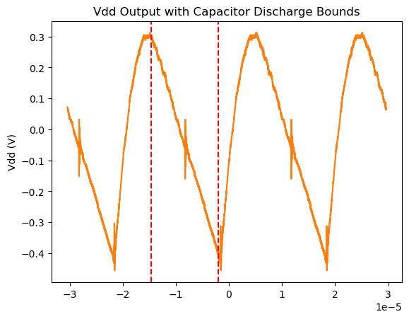

```python
# Define indices within which to calculate the slope
ind1 = 7887
ind2 = 14198

plt.plot(t2_9_data["X"], t2_9_data["CH2"], label="Vdd", color='tab:orange', linestyle="-")
plt.ylabel("Vdd (V)")

plt.axvline(x = t2_9_data["X"][ind1], linestyle='--', color='r', label="Lower Slope Limit")
plt.axvline(x = t2_9_data["X"][ind2], linestyle='--', color='r', label="Lower Slope Limit")
plt.title("Vdd Output with Capacitor Discharge Bounds")

# Calculate the rate of change of voltage
Vdd_diff = np.gradient(t2_9_data["CH2"][ind1:ind2], t2_9_data["X"][ind1:ind2])
slope = Vdd_diff.mean()

I_c = 1.80
capacitance = I_c / slope
print(f"Capacitance of the output capacitor with a 9V output: {capacitance} F")
```

As shown above, the calculated output capacitance is $32.6\mu F$ with the 9V output (taking the absolute value given the capacitor is discharging, resulting in a negative slope). The same calculation can be repeated for the 4V and 7V outputs.

```python
ind1 = 6927
ind2 = 11841

Vdd_7_diff = np.gradient(t2_7_data["CH2"][ind1:ind2], t2_7_data["X"][ind1:ind2])
slope_7 = Vdd_7_diff.mean()

I_c_7 = 7.11 / 5

capacitance_7 = I_c_7 / slope_7
print(f"Capacitance of the output capacitor with a 7V output: {capacitance_7} F")

ind1 = 6537
ind2 = 11446

Vdd_4_diff = np.gradient(t2_4_data["CH2"][ind1:ind2], t2_4_data["X"][ind1:ind2])
slope_4 = Vdd_4_diff.mean()

I_c_4 = 4.01 / 5

capacitance_4 = I_c_4 / slope_4
print(f"Capacitance of the output capacitor with a 4V output: {capacitance_4} F")
```

```
Capacitance of the output capacitor with a 7V output: -3.724791044775978e-05 F
Capacitance of the output capacitor with a 4V output: -4.364764966741005e-05 F
```

Similarly, the 7V output results in a $37.2 \mu C$ capacitance, and the 4V output results in a $43.6 \mu C$ capacitance. Notably, these are all less than the actual value of the output capacitance, $88 \mu F$$ (given there are 4 $22 \mu F$ capacitors in parallel). This is likely due to our simplifying calculations not taking into account the parasitic capacitance of the transformer and other components and other intricacies of using real-world, non-ideal components throughout the converter.